# Сообщество Зоопланктона Обской губы

# Связь сообщества зоопланктона с параметрами среды

*NB! Схема обработки данных по зоопланктону была аналогична схеме анализа данных по фитопланктону.*

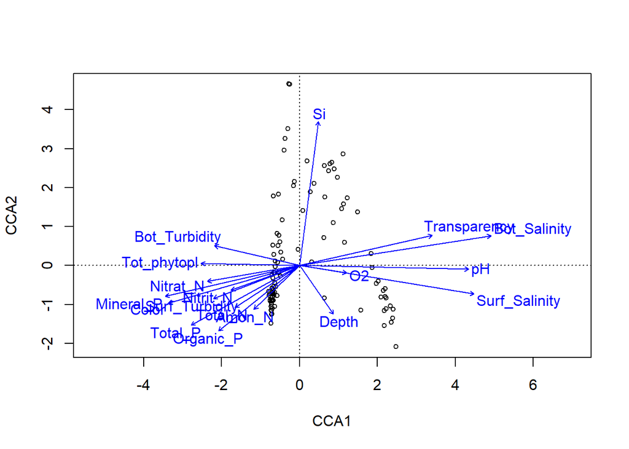

**Рисунок 2.** Ординация проб в первой и второй канонических корреспондентных осях, описывающих связи сообщества зоопланктона с параметрами среды

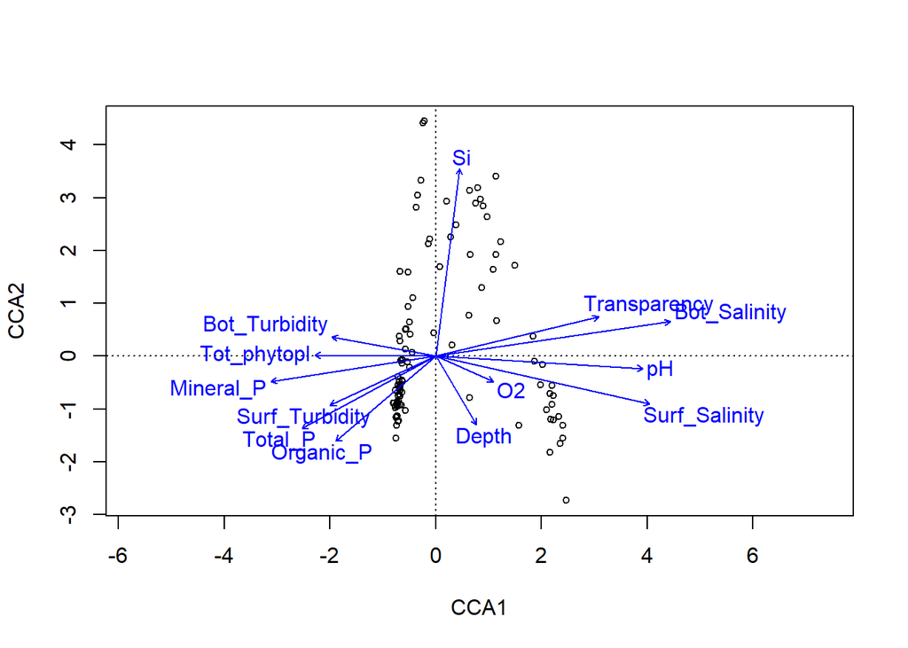

Градиент ССA1 отражает как видовое разнообразие, падающее по мере увеличения значений ССA1 (Рисунок 5, A), но при этом не связан с общим обилием зоопланктона (Рисунок 5, B). Соленость придонной и поверхностной водной массы возрастает по мере увеличения значений CCA1 (Рисунок 5, C, D).

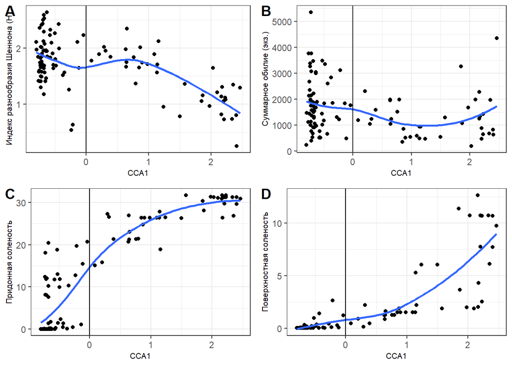

**Рисунок 5.** Связь значений CCA1 c видовым разнообразием сообщества зоопланктона, его общим обилием и значениями придонной и поверхностной солености. Приведены LOESS-линии регрессии.

В пространстве сообщество зоопланктона демонстрирует градиент очень близкий к градиенту солености и, в целом, совпадает с градиентом распределения фитопланктона (Рисунок 6, A). Однако следует отметить, что более разнообразное сообщество зоопланктона представлено в опресненной части губы. Это говорит о том, планктонное сообщество, принесенное с водами морского происхождения, угнетается под воздействием пресной воды.

Вторая каноническая ось связана с концентрацией кремния (Рисунок 4): чем выше значения CCA2, тем больше концентрация этого элемента. Сообщества зоопланктона, приуроченные к участкам с высокой концентрацией кремния, представлены на стыке между водными массами устья губы и верховий реки (Рисунок 6, B).

Для дальнейшего анализа все станции были разбиты на две условные группы в соответствии с величиной значений первой канонической оси (эти группы выделены независимо от разделения на группы в сообществе фитопланктона). К первой группе, условно обозначаемой, как сообщество зоопланктона, представленного в осолоненной водной массе (“Saline”), были отнесены следующие станции: O1, O10, O11, O12, O14, O15, O16, O18, O19, O2, O21, O22, O24, O25, O28, O29, O3, O30, O32, O33, O34, O35, O36, O37, O38, O39, O4, O40, O41, O42, O43, O44, O45, O46, O5, O6, O7, O8, O9. Ко второй группе (“Fresh”) были отнесены станции: O101, O102, O104, O105, O107, O108, O109, O111, O112, O13, O27, O31, O47, O48, O49, O50, O51, O52, O53, O54, O55, O56, O57, O58, O59, O60, O61, O62, O63, O64, O65, O66, O67, O68, O69, O70, O71, O72, O73, O74, O75, O76, O77, O78, O79, O80, O81, O82, O83, O84, O85, O86, O87, O88, O89, O90, O91, O92, O93, O94, O95, O96, O97, O98, O99. Пространственное распределение станций двух разных групп приведено на Рисунок 6.

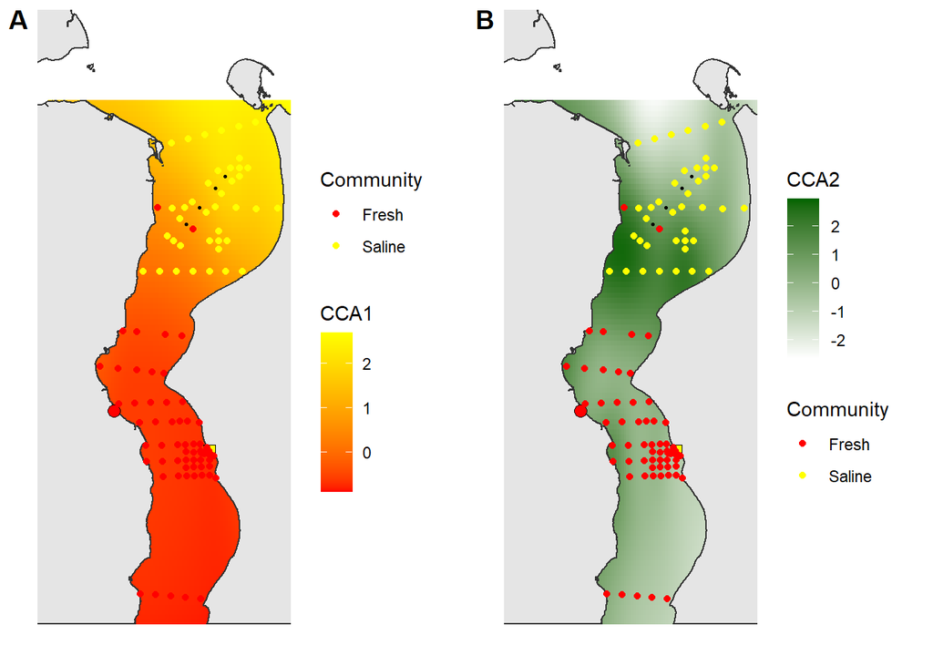

# Связь сообщества с техногенными факторами

Существенных связей видового разнообразия зоопланктона и его суммарного обилия с концентрацией взвешенных частиц выявлено не было. В связи с этим была проанализирована связь со второй ковариатой, потенциально отражающей уровень техногенной нагрузки - *судовой нагрузкой*.

Для анализа связи структуры сообщества зоопланктона с уровнем судовой нагрузки были построены две регрессионные модели. В качестве переменной отклика в первой модели выступала величина коэффициента Шеннона (*H*), описывающая видовое разнообразие сообщества, а во второй - общая численность зоопланктона (*Total_N*). В обеих моделях в качестве предикторов выступали тип сообщества (дискретный фактор с двумя градациями: *Saline* vs *Fresh*), логарифм судовой нагрузки (*Log_Ships*) и взаимодействие этих предикторов.

В первой модели значимого взаимодействия предикторов выявлено не было (Табл. 1), что позволило оценить их роль в варьировании значений коэффициента Шеннона. Приведенные данные свидетельствуют о более высоком разнообразии пресноводного сообщества. Судовая нагрузка оказывает негативное влияние на видовое разнообразие как пресноводного, так и морского сообщества (Табл. 1, Рисунок 7, A).

Модель, описывающая зависимость общего обилия зоопланктона от типа сообщества и уровня судовой нагрузки (Табл. 2) характеризовалась статистически значимым взаимодействием предикторов. Поскольку на фоне значимого взаимодействия анализ главных эффектов невозможен, был построен график, визуализирующий характер связей, описываемых моделью (Рисунок 7, B). Обилие зоопланктона в пресноводном сообществе не демонстрировало значимой связи с уровнем судовой нагрузки. Однако общее обилие зоопланктона морского происхождения демонстрировало некоторую отрицательную связь с уровнем судовой нагрузки.

Таким образом, присутствие судов в акватории приводит к снижению биоразнообразия и общего обилия зоопланктона. Однако наиболее зависимым от влияние этого фактора является сообщество морского происхождения.

Таблица 1. Параметры регрессионной модели, описывающей зависимость видового разнообразия зоопланктона от типа сообщества и величины судовой нагрузки

| term | estimate | std.error | statistic | p.value |
| --- | --- | --- | --- | --- |
| (Intercept) | 1.9228 | 0.0615 | 31.2525 | 0.0000 |
| CommunitySaline | -0.4248 | 0.0989 | -4.2965 | 0.0000 |
| Log_Ships | -0.0601 | 0.0216 | -2.7766 | 0.0066 |
| CommunitySaline:Log_Ships | -0.0496 | 0.0623 | -0.7948 | 0.4286 |

Таблица 2. Параметры регрессионной модели, описывающей зависимость общего обилия зоопланктона от типа сообщества и величины судовой нагрузки

| term | estimate | std.error | statistic | p.value |
| --- | --- | --- | --- | --- |
| (Intercept) | 7.3678 | 0.0910 | 80.9573 | 0.0000 |
| CommunitySaline | -0.2662 | 0.1462 | -1.8205 | 0.0717 |
| Log_Ships | -0.0292 | 0.0320 | -0.9127 | 0.3636 |
| CommunitySaline:Log_Ships | -0.1923 | 0.0922 | -2.0847 | 0.0396 |

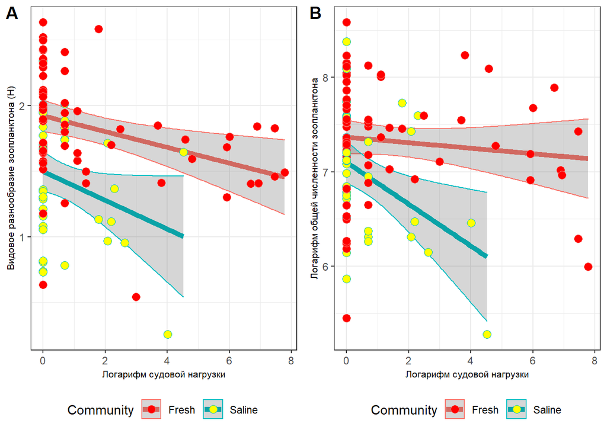

**Рисунок 7.** Зависимость видового разнообразия сообщества зоопланктона (A) и его общего обилия (B) от типа сообщества и величины судовой нагрузки.

# Приложение

### Список видов, характерных для водной массы морского происхождения.

| Таксоны |
| --- |
| Acartia longiremis |
| Acartia sp. |
| Bivalvia larvae |
| Calanus glacialis |
| Cerianthus sp. |
| Harpacticus uniremis |
| Jaschnovia tolli |
| Larvae Polychaeta |
| Mesochra lilljeborgii |
| Nauplia Acartia |
| Nauplia Pseudocalanus |
| Nauplia Temora |
| Obelia longissima |
| Oithona similis |
| Pseudocalanus acuspes |
| Pseudocalanus minutus |
| Rathkea octopunctata |
| Senecella calanoides |
| Synchaeta tamara |
| Temora longicornis |

### Список видов, характерных для водной массы речного происхождения.

| Таксоны |
| --- |
| Acanthocyclops vernalis |
| Bosmina longirostris |
| Brachionus angularis |
| Bythotrephes longimanus |
| Cyclops abyssorum |
| Cyclops scutifer |
| Daphnia hyalina |
| Diacyclops bisetotus |
| Eucyclops serrulatus |
| Eudiaptomus gracilis |
| Eurytemora lacustris |
| Kellicottia longispina |
| Keratella quadrata |
| Leptodora kindtii |
| Megacyclops viridis |
| Mesocyclops leuckarti |
| Notholca acuminata |
| Polyarthra dolichoptera |
| Thermocyclops oithonoides |
| Trichocerca capucina |